# Visualizing Distributions

Ellie Grace Moore

2/16/2022

For this first example, we will work with the `biomarker` dataset. This involves several variables that are related to the health of elderly patients. The variables are the following:

- **PPFEV1**: the forced expiritory volume of air the patient can exhale in one second
- **DSS**: patient scores on mental exercise
- **sixmpace**: speed a person can walk six meters
- **grip**: how tighly a patient can grip an object

The first few rows of the dataframe are shown below. We also include a scatterplot matrix to get a preliminary idea of the variables relation to each other.

| PPFEV1 | DSS | sixmpace | grip |
| --- | --- | --- | --- |
| 88.59226 | 23 | 1.056339 | 38 |
| 93.38657 | 48 | 1.229509 | 20 |
| 95.54811 | 14 | 1.500000 | 38 |
| 64.87961 | 3 | 1.583114 | 54 |
| 100.24847 | 23 | 1.324504 | 26 |
| 68.86629 | 23 | 1.073346 | 34 |

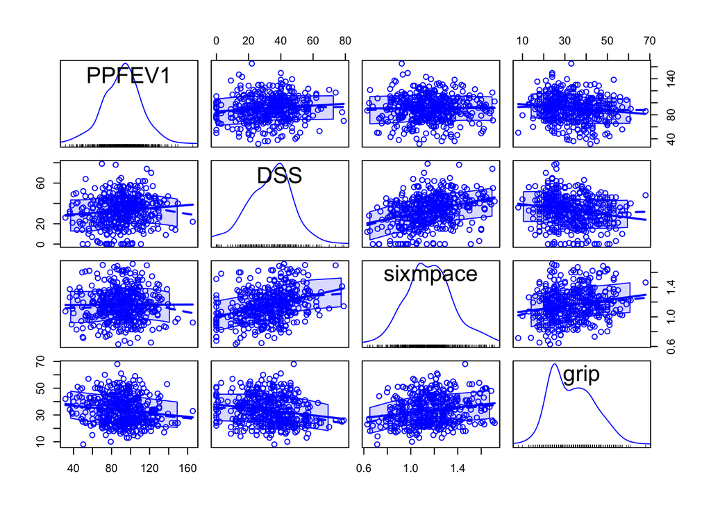

According to the Q-Q Plots and histograms below, it appears that **DSS** and **grip** least represent a normal distribution. However between these two grip is arguably “less normal” being rather right skewed.

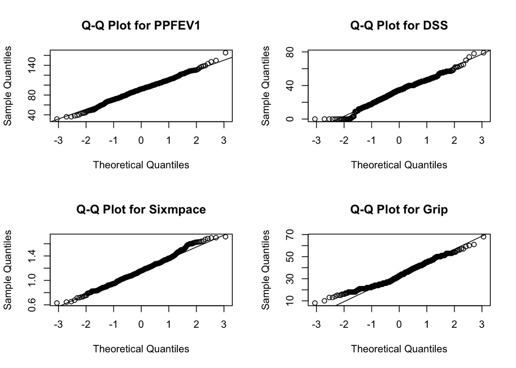

```r
par(mfrow = c(2,2))
qqnorm(biomarker$PPFEV1, main = "Q-Q Plot for PPFEV1")
qqline(biomarker$PPFEV1)
qqnorm(biomarker$DSS, main = "Q-Q Plot for DSS")
qqline(biomarker$DSS)
qqnorm(biomarker$sixmpace, main = "Q-Q Plot for Sixmpace")
qqline(biomarker$sixmpace)
qqnorm(biomarker$grip, main = "Q-Q Plot for Grip")
qqline(biomarker$grip)
```

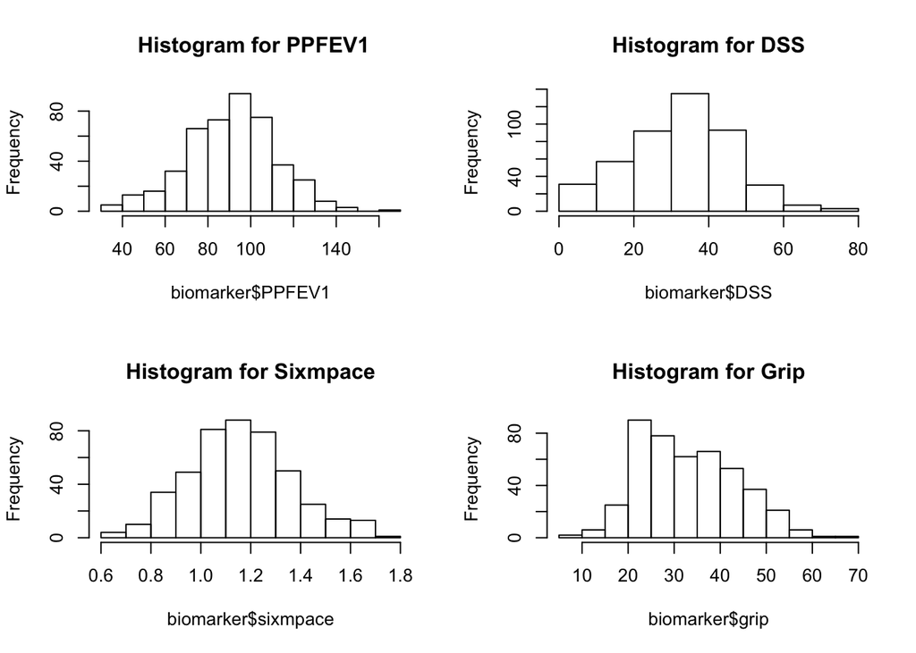

```r
par(mfrow = c(2,2))
hist(biomarker$PPFEV1, main = " Histogram for PPFEV1")
hist(biomarker$DSS, main = "Histogram for DSS")
hist(biomarker$sixmpace, main = "Histogram for Sixmpace")
hist(biomarker$grip, main = "Histogram for Grip")
```

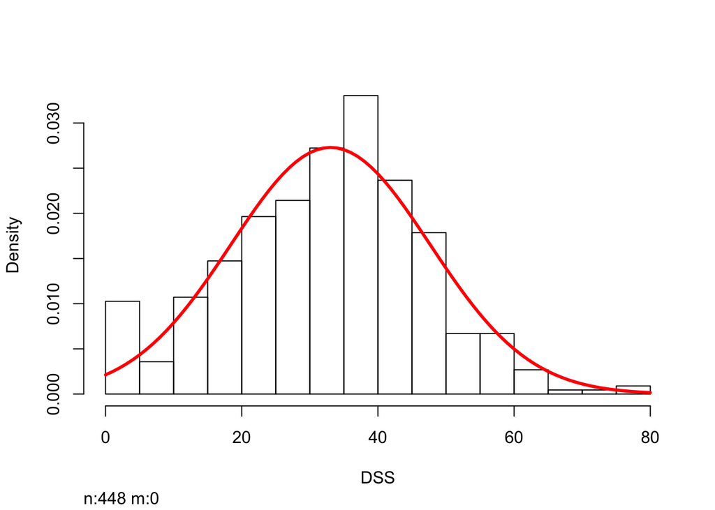

```r
hist(biomarker[,2], main="DSS", xlab="DSS", freq=FALSE)
h=seq(0,80,by=1)
v=dnorm(h,mean(biomarker$DSS),sqrt(S[2,2]))
lines(h,v, col="red", lwd=3)
```

In my opinion, since the discrete data appears to follow a normal distribution, I find it okay to use a continuous normal for the `DSS` variable. This way we are able to learn more about the variable itself.

### 4. (a)

This first plot is more “raw” code that allows me to play around with different bandwidths. Then the next chunk of code outputs the optimal bandwidth according to R (and thus giving us a much more viewer-friendly kernel density estimate).

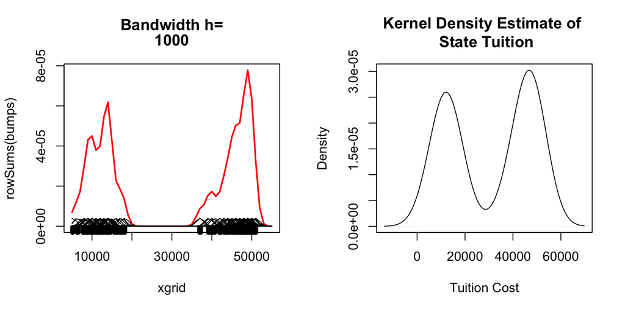

```r
par(mfrow = c(1,2))

x=colleges$TuitionState
n=length(x)
h=1000
bumps=sapply(x, function(a) gauss((xgrid-a)/h)/(n*h))

plot(xgrid, rowSums(bumps), type="l", lwd=2, col="red", main = c("Bandwidth h=",h))
rug(x, lwd=6)
out=apply(bumps, 2, function(b) lines(xgrid, b))
plot(density(colleges$TuitionState), main = "Kernel Density Estimate of \n State Tuition", xlab = "Tuition Cost")
```

To further visulize the data, we will construct bagplots of the graduation rate as well as the fall acceptance rate.

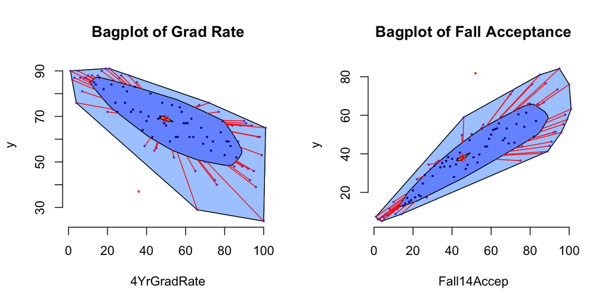

```r
par(mfrow=c(1,2))
bagplot(colleges$`4YrGradRate`, xlab = "4YrGradRate", main = "Bagplot of Grad Rate")
bagplot(colleges$Fall14Accep, xlab = "Fall14Accep", main = "Bagplot of Fall Acceptance")
```

Lastly, we can visulize the distribution even *further* by constructing a 3D scatterplot. There is no perfect angle for viewing a 3D Scatterplot, but after looking at different angles, this angle (70 degrees) was determined the most clear.

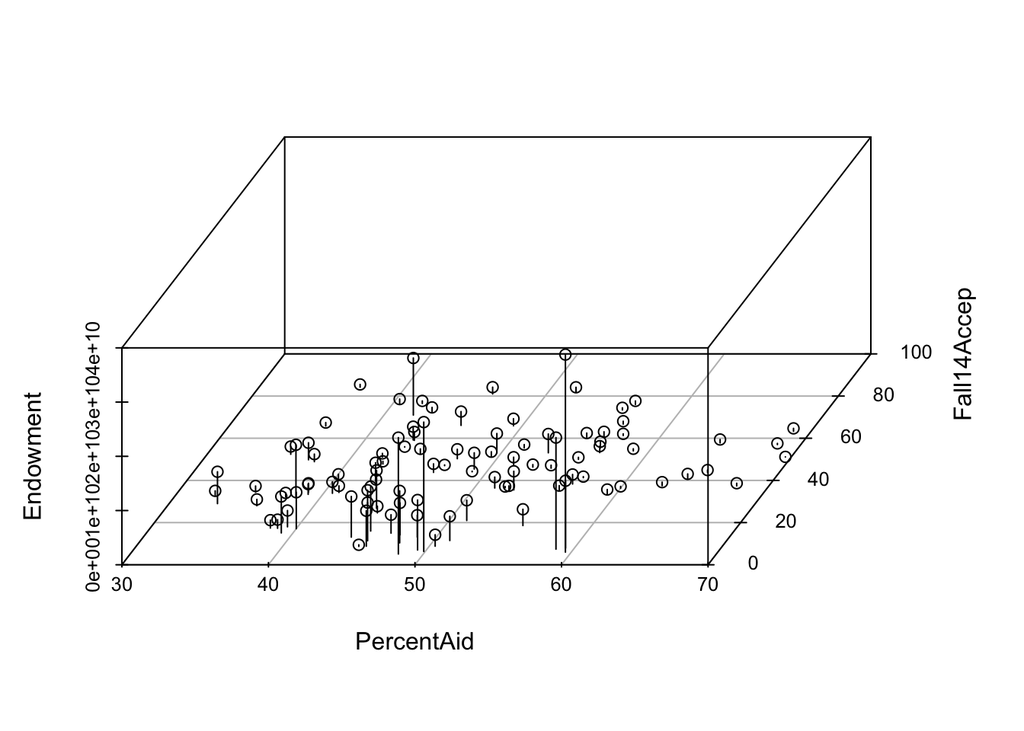

```r
library(scatterplot3d)
with(colleges, scatterplot3d(PercentAid, Fall14Accep, Endowment, type="h", angle=70))
```